# Chron’s Disease DESeq analysis

Stefano Catanzaro, Marina Piccari, Adelina Vivaldo

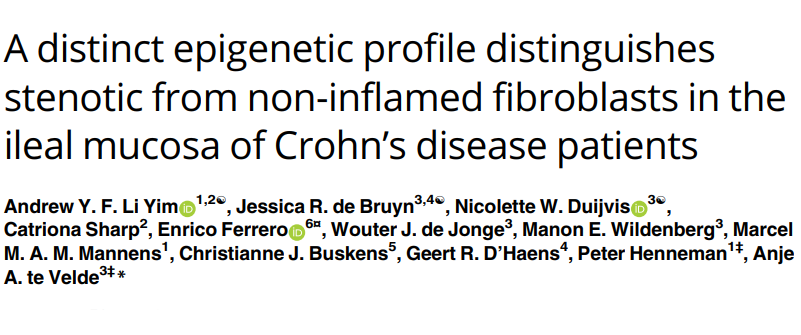

# Introduction

#### **Aim of the paper**

*Understand the pathophysiology of fibro-stenotic complications due to intestinal inflammation characteristic of Crohn’s disease.*

#### **Disease development**

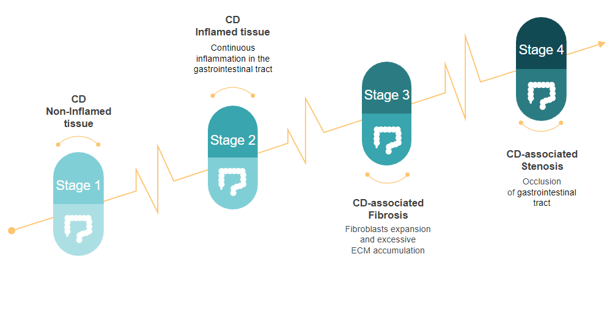

#### **Patients and samples**

21 samples from 14 unique patients.

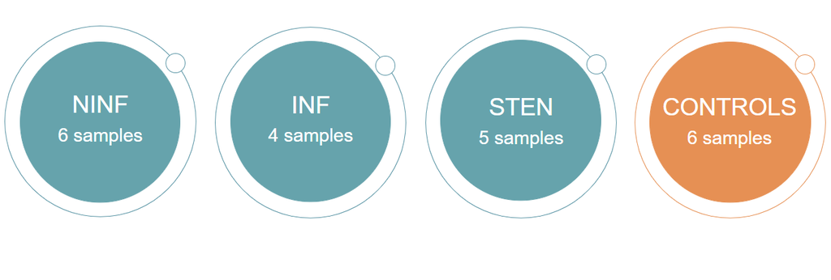

#### **Data pre-processing**

For the differential gene expression analysis, raw sequences were merged per sample and checked for quality using **FastQC** and **MultiQC**. The sequences were then aligned to the reference **genome GRCh38** using **STAR**, and sorted and converted into binary files using **SAMtools**. Reads were counted and annotated using the Ensembl annotations using the **featureCounts** module in the Subread package.

# Setup

All the necessary libraries for the analysis are uploaded.

```r
library("SummarizedExperiment")
library("ggplot2")
library("RColorBrewer")
library("clusterProfiler")
library("genefilter")
library("pheatmap")
library("org.Hs.eg.db")
library("fdrtool")
library("DESeq2")
library("limma")
library("ashr")
```

```r
df <- read.delim("GENDX000019_GeneMatrix_rawCounts.txt", row.names=1)
metadata <- read.delim("GEND000019-meta.txt", row.names=5)

df1 <- df[rowSums(df>1) >= 11,]
genes <- row.names(df1)
df1<- as.data.frame(lapply(df1, as.integer))

row.names(df1) <- substr(genes, 1, 15)

head(df1)
```

```
##                 GENS00000691 GENS00000692 GENS00000693 GENS00000694
## ENSG00000000003          549          652          380          558
## ENSG00000000419          565          541          477          549
## ENSG00000000457          201          144           78           96
## ENSG00000000460          139           73           14           23
## ENSG00000000971         5722         8634         2483         1819
## ENSG00000001036         1702         1771         1613         1917
##                 GENS00000695 GENS00000696 GENS00000697 GENS00000698
## ENSG00000000003          431          299          447          636
## ENSG00000000419          522          422          299          574
## ENSG00000000457           93           97           99           87
## ENSG00000000460           81           65           18           18
## ENSG00000000971          441          906         3661         1019
## ENSG00000001036         1576         1860         1283         1738
##                 GENS00000699 GENS00000700 GENS00000701 GENS00000702
## ENSG00000000003          318          492          384          514
## ENSG00000000419          398          445          288          316
## ENSG00000000457           71          160          139           47
## ENSG00000000460           62           12           58           21
## ENSG00000000971         1725         1337         2753         2555
## ENSG00000001036         1149         1555         1715         1102
##                 GENS00000703 GENS00000704 GENS00000705 GENS00000706
## ENSG00000000003          498          576          591          349
## ENSG00000000419          304          496          573          312
## ENSG00000000457           83           70          139           81
## ENSG00000000460           37           72           48           57
## ENSG00000000971         3159         2042         1429         2298
## ENSG00000001036         1365         1959         1997         1678
##                 GENS00000707 GENS00000708 GENS00000709 GENS00000710
## ENSG00000000003          347          462          279          445
## ENSG00000000419          418          430          297          555
## ENSG00000000457           65           92           80          116
## ENSG00000000460           32           26           60           57
## ENSG00000000971          189          991         1034          439
## ENSG00000001036         1255         2327         1252         2395
##                 GENS00000711
## ENSG00000000003          242
## ENSG00000000419          459
## ENSG00000000457          102
## ENSG00000000460           54
## ENSG00000000971         2000
## ENSG00000001036         2192
```

```r
metadata$Age.Level <-  cut(metadata$Age, c(17, 40, 80))
metadata[, c("Gender", "Disease", "Disease.State", "Age", "Age.Level")]
```

```
##              Gender         Disease Disease.State Age Age.Level
## GENS00000691 female Healthy Control             -  57   (40,80]
## GENS00000692 female Healthy Control             -  57   (40,80]
## GENS00000693 female Healthy Control             -  57   (40,80]
## GENS00000694   male Healthy Control             -  61   (40,80]
## GENS00000695   male Healthy Control             -  20   (17,40]
## GENS00000696   male Healthy Control             -  75   (40,80]
## GENS00000697 female Crohn's Disease  non-inflamed  28   (17,40]
## GENS00000698   male Crohn's Disease  non-inflamed  42   (40,80]
## GENS00000699   male Crohn's Disease  non-inflamed  21   (17,40]
## GENS00000700 female Crohn's Disease  non-inflamed  57   (40,80]
## GENS00000701   male Crohn's Disease  non-inflamed  26   (17,40]
## GENS00000702 female Crohn's Disease  non-inflamed  44   (40,80]
## GENS00000703 female Crohn's Disease      inflamed  44   (40,80]
## GENS00000704   male Crohn's Disease      inflamed  26   (17,40]
## GENS00000705   male Crohn's Disease      inflamed  65   (40,80]
## GENS00000706 female Crohn's Disease      inflamed  28   (17,40]
## GENS00000707   male Crohn's Disease      stenotic  19   (17,40]
## GENS00000708 female Crohn's Disease      stenotic  46   (40,80]
## GENS00000709 female Crohn's Disease      stenotic  46   (40,80]
## GENS00000710   male Crohn's Disease      stenotic  18   (17,40]
## GENS00000711   male Crohn's Disease      stenotic  26   (17,40]
```

# DE analysis (CD vs non-CD)

In order to investigate in deep the differential expression of genes, two different designs are carried out. The first one is focused in comparing **Healthy controls** vs **Chron’s disease samples**, correcting for Gender, Age and Passage number (the number of times the cell culture has been subcultured).

```r
dds1 <- DESeqDataSetFromMatrix(df1, colData=metadata,
                               design = ~ Gender + Age.Level + Development.Stage + Disease)

rld1 <- rlog(dds1, blind=FALSE)
```

### PCA plots

A principal component analysis (PCA) plot allows to visualize the patterns of variability in the data.

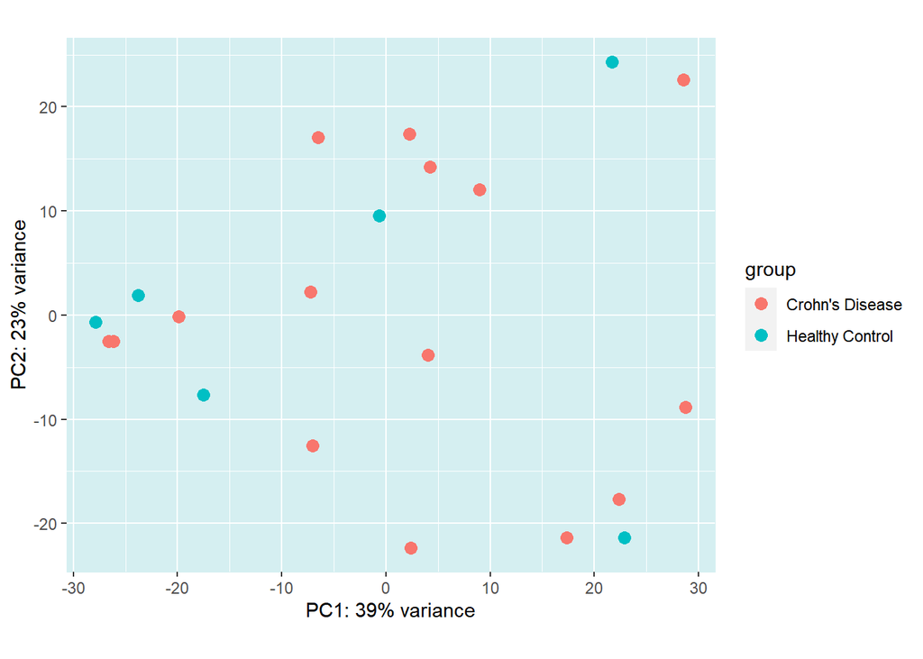

```r
plotPCA(rld1, intgroup = c("Disease")) +
  theme(panel.background = element_rect(fill = "#d5eff1",colour = "#d5eff1",size = 0.5,
  linetype = "solid"), panel.grid.major = element_line(size = 0.5, linetype = 'solid',
  colour = "white"), panel.grid.minor = element_line(size = 0.25, linetype = 'solid',
  colour = "white"))
```

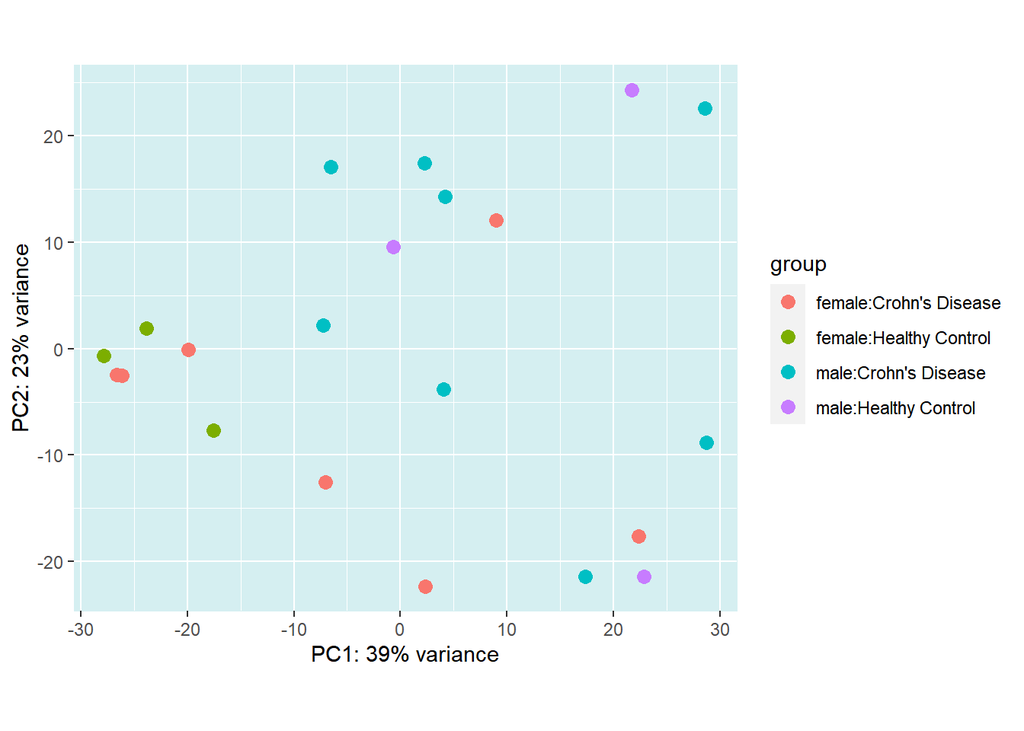

```r
plotPCA(rld1, intgroup = c("Gender", "Disease")) +
  theme(panel.background = element_rect(fill = "#d5eff1",colour = "#d5eff1",size = 0.5,
  linetype = "solid"), panel.grid.major = element_line(size = 0.5, linetype = 'solid',
  colour = "white"), panel.grid.minor = element_line(size = 0.25, linetype = 'solid',
  colour = "white"))
```

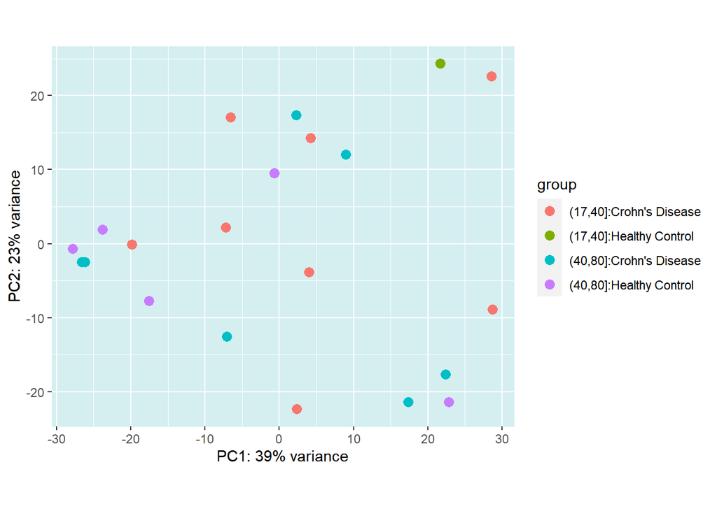

```r
plotPCA(rld1, intgroup = c("Age.Level", "Disease")) +
  theme(panel.background = element_rect(fill = "#d5eff1",colour = "#d5eff1",size = 0.5,
  linetype = "solid"), panel.grid.major = element_line(size = 0.5, linetype = 'solid',
  colour = "white"), panel.grid.minor = element_line(size = 0.25, linetype = 'solid',
  colour = "white"))
```

### DESeq Results

**DESeq()** function is applied to perform the actual differential expression analysis and the results are stored in res1 object.

```r
dds1 <- DESeq(dds1)
res1<-results(dds1)
summary(res1)
```

```
##
## out of 16946 with nonzero total read count
## adjusted p-value < 0.1
## LFC > 0 (up)       : 11, 0.065%
## LFC < 0 (down)     : 60, 0.35%
## outliers [1]       : 0, 0%
## low counts [2]     : 0, 0%
## (mean count < 1)
## [1] see 'cooksCutoff' argument of ?results
## [2] see 'independentFiltering' argument of ?results
```

71 genes show a significant up or down regulation (padj < 0.1). They are now ordered by a log2FoldChange decreasing order.

```r
resSig1 <- subset(res1, padj < 0.1)
resSig1 <- resSig1[order(resSig1$log2FoldChange, decreasing=T), ]
head(resSig1)
```

```
## log2 fold change (MLE): Disease Healthy.Control vs Crohn.s.Disease
## Wald test p-value: Disease Healthy.Control vs Crohn.s.Disease
## DataFrame with 6 rows and 6 columns
##                  baseMean log2FoldChange     lfcSE      stat      pvalue
##                 <numeric>      <numeric> <numeric> <numeric>   <numeric>
## ENSG00000230202   32.2325        4.40160  0.941637   4.67441 2.94798e-06
## ENSG00000078399   35.7767        3.33318  0.935691   3.56227 3.67669e-04
## ENSG00000119508  453.5963        1.67786  0.470460   3.56644 3.61869e-04
## ENSG00000128573   58.7475        1.63795  0.447982   3.65630 2.55883e-04
## ENSG00000165030  686.9038        1.07884  0.256914   4.19923 2.67828e-05
## ENSG00000019549  812.2573        1.01910  0.279111   3.65123 2.60983e-04
##                       padj
##                  <numeric>
## ENSG00000230202 0.00832607
## ENSG00000078399 0.08900737
## ENSG00000119508 0.08887292
## ENSG00000128573 0.07303067
## ENSG00000165030 0.01973313
## ENSG00000019549 0.07303067
```

```r
resLFC1 <- results(dds1, lfcThreshold=1)
summary(resLFC1)
```

```
##
## out of 16946 with nonzero total read count
## adjusted p-value < 0.1
## LFC > 1.00 (up)    : 0, 0%
## LFC < -1.00 (down) : 2, 0.012%
## outliers [1]       : 0, 0%
## low counts [2]     : 0, 0%
## (mean count < 1)
## [1] see 'cooksCutoff' argument of ?results
## [2] see 'independentFiltering' argument of ?results
```

### Plot results

#### **Dot plots**

The function **plotCount()** shows the counts of sequencing reads for a particular gene of interest in each sample. The genes selected are those presenting the smallest padj.

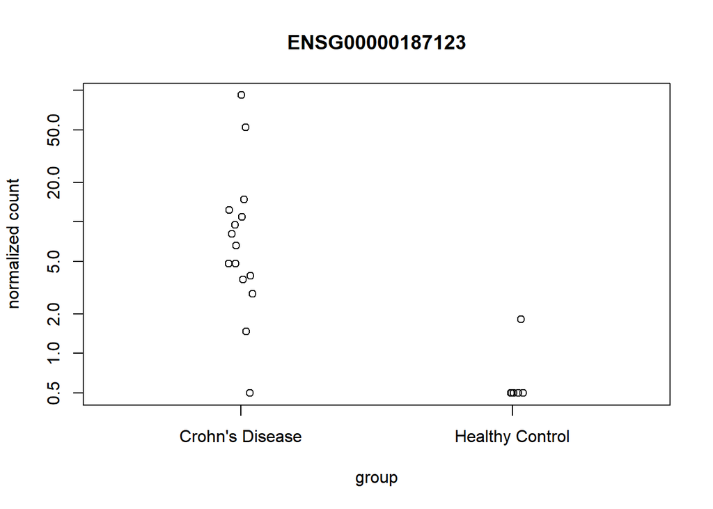

```r
topGenes1<-rownames(res1[order(res1$padj, decreasing=F),])

plotCounts(dds1, gene=topGenes1[1], intgroup=c("Disease"))
```

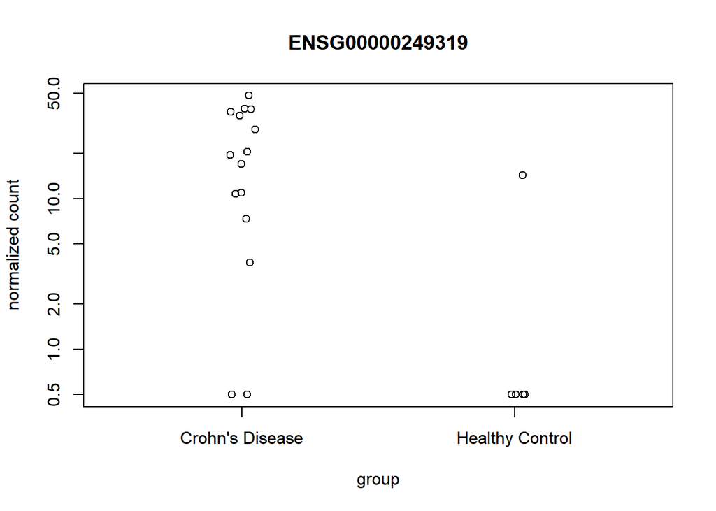

```r
plotCounts(dds1, gene=topGenes1[5], intgroup=c("Disease"))
```

#### **MA plots**

The MA plot represents the LFC of the genes as a function of the average expression between the two conditions, which are theoretically equivalent information between the two experimental conditions.

```r
resultsNames(dds1)
```

```
## [1] "Intercept"
## [2] "Gender_male_vs_female"
## [3] "Age.Level_.40.80._vs_.17.40."
## [4] "Development.Stage_passage.2_vs_passage.1"
## [5] "Development.Stage_passage.3_vs_passage.1"
## [6] "Development.Stage_passage.4_vs_passage.1"
## [7] "Development.Stage_passage.5_vs_passage.1"
## [8] "Disease_Healthy.Control_vs_Crohn.s.Disease"
```

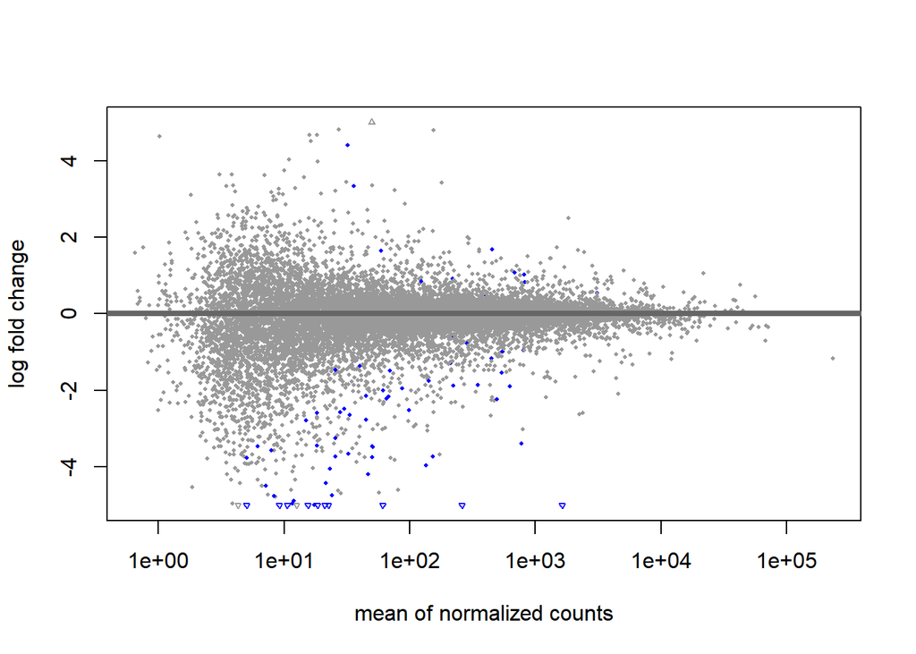

```r
res1_Disease_MA <- results(dds1, contrast = list("Disease_Healthy.Control_vs_Crohn.s.Disease" ))
DESeq2::plotMA(res1_Disease_MA, ylim=c(-5,5))
```

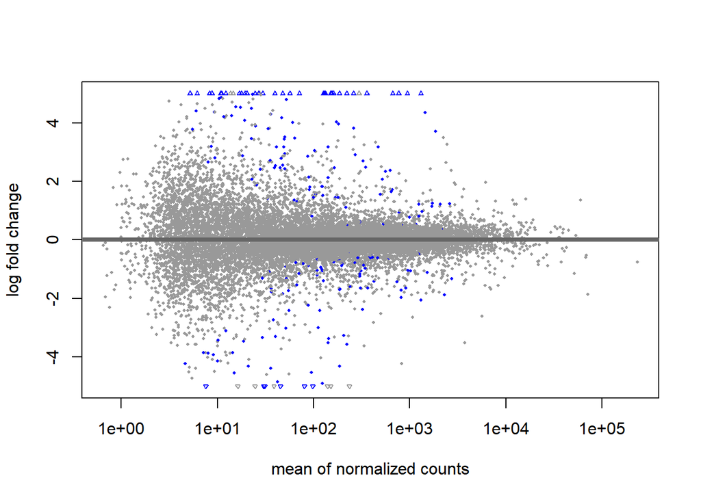

```r
res1_Gender_MA <- results(dds1, contrast = list("Gender_male_vs_female"))
DESeq2::plotMA(res1_Gender_MA, ylim=c(-5,5))
```

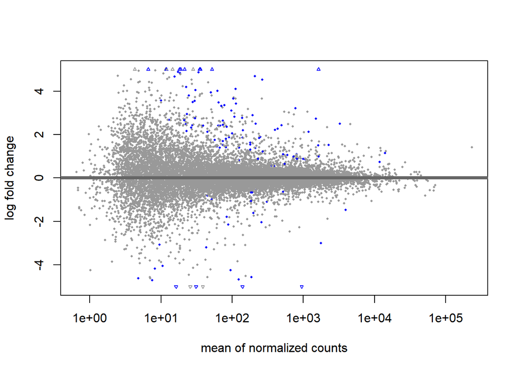

```r
res1_Age_MA <- results(dds1, contrast = list("Age.Level_.40.80._vs_.17.40."))
DESeq2::plotMA(res1_Age_MA, ylim=c(-5,5))
```

#### **P-value distribution**

An histogram of p-values distribution is plotted to investigate the reliability of the analysis.

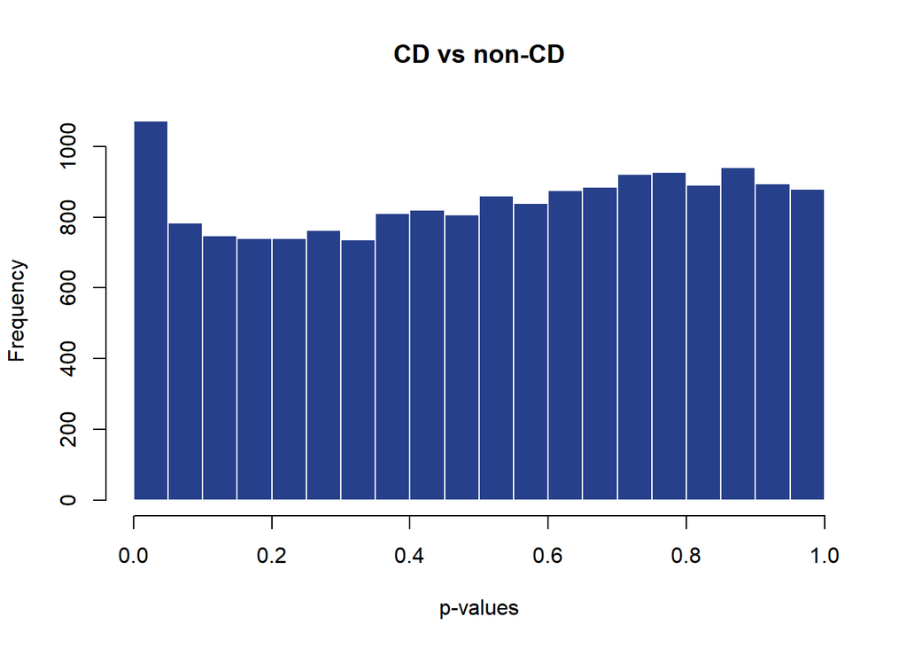

```r
hist(res1$pvalue[res1$baseMean > 1], breaks=0:20/20, col="royalblue4", border="white", main = "CD vs non-CD", xlab = "p-values")
```

Since a proper p-value distribution has a rectangular shape with a peak at 0, a correction is performed.

```
## Step 1... determine cutoff point
## Step 2... estimate parameters of null distribution and eta0
## Step 3... compute p-values and estimate empirical PDF/CDF
## Step 4... compute q-values and local fdr
## Step 5... prepare for plotting
```

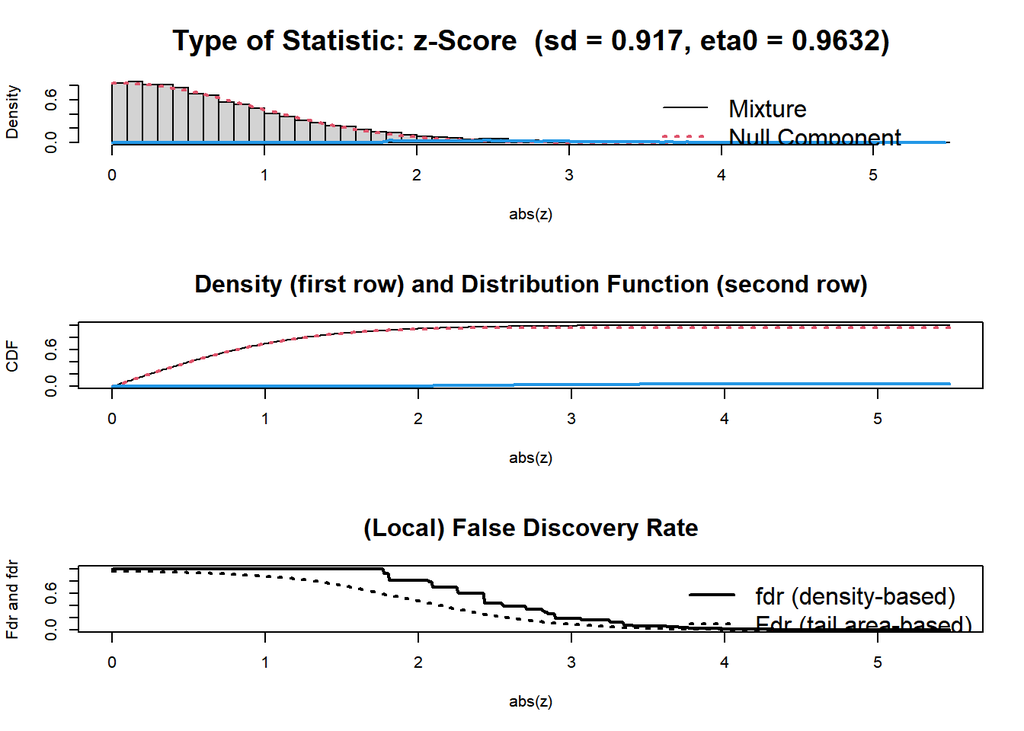

```r
res1_corr <- res1[ !is.na(res1$padj),]
res1_corr <- res1_corr[ !is.na(res1_corr$pvalue), ]
res1_corr <- res1_corr[, -which(names(res1_corr) == "padj")]
res_fdr1 <- fdrtool(res1_corr$stat, statistic= "normal", plot = T)
```

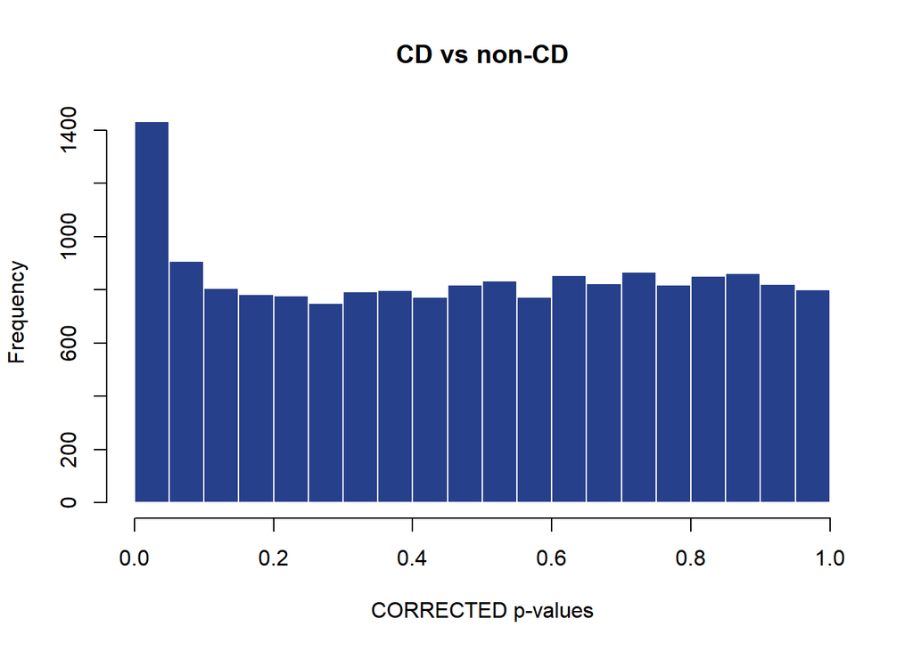

```r
res1_corr[,"padj"] <- p.adjust(res_fdr1$pval, method = "BH")
hist(res_fdr1$pval, col = "royalblue4", xlab = "CORRECTED p-values", border="white", main = "CD vs non-CD")
```

#### **Heatmap**

A clustered heatmap is plotted over Disease and Gender using the 20 more variant genes among samples. Since the influence of Gender on gene expression is evident, a new heatmap is plotted after removing Batch effect of Gender.

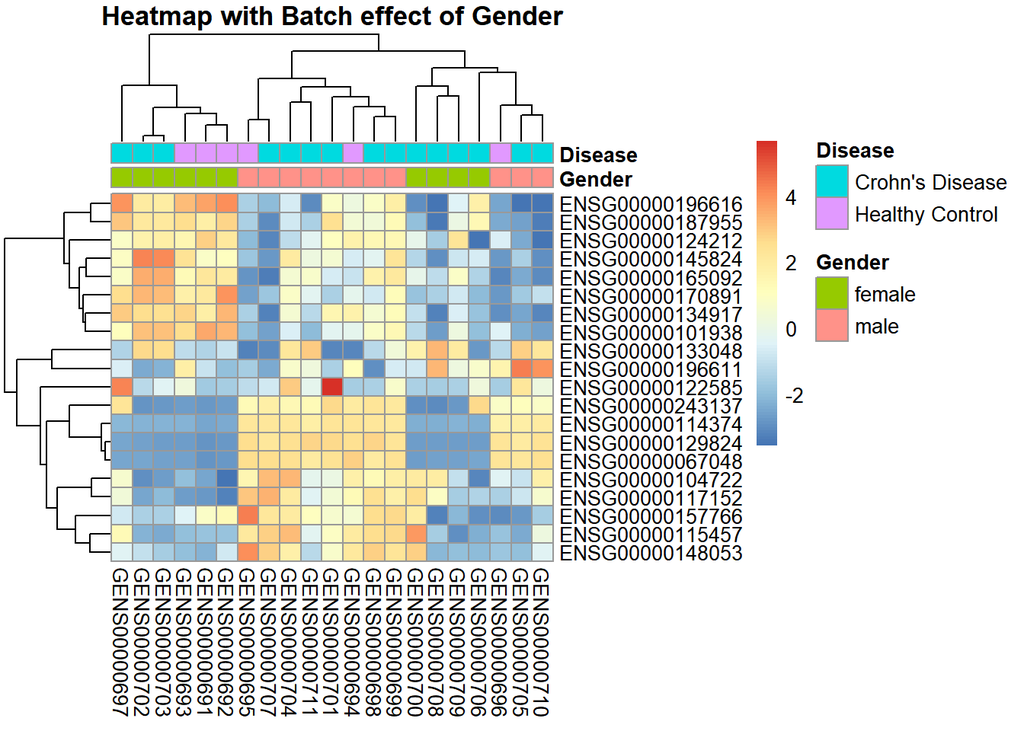

```r
library("genefilter")
library("clusterProfiler")
library("pheatmap")

#More variant genes among samples
topVarGenes1 <- order(rowVars(assay(rld1)),decreasing=TRUE)
mat1 <- assay(rld1)[topVarGenes1, ]
mat1 <- mat1 - rowMeans(mat1)

new_mat1 <- removeBatchEffect(mat1, batch= colData(rld1)$Gender)

df_clust1 <- as.data.frame(colData(rld1)[,c("Gender","Disease")])


pheatmap(head(mat1, 20), annotation_col=df_clust1, main = "Heatmap with Batch effect of Gender", cluster_cols = T)
```

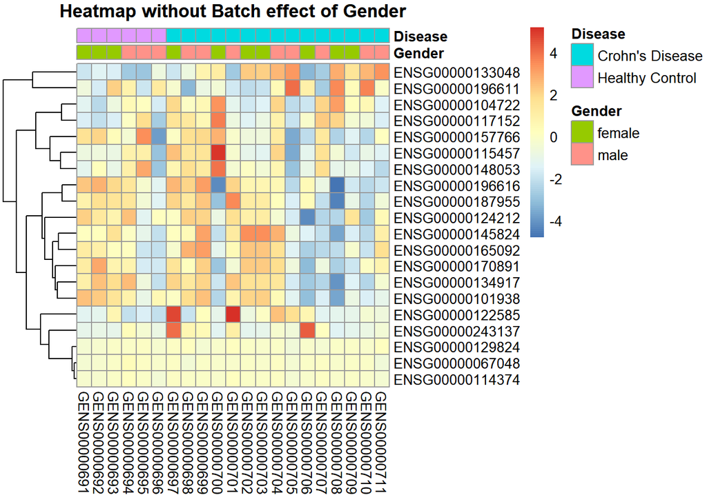

```r
pheatmap(head(new_mat1, 20), annotation_col=df_clust1, main = "Heatmap without Batch effect of Gender",cluster_cols = F)
```

### Enrichment

Once the differentially expressed genes have been identified, enrichment analysis can be used to identify the biological pathways, gene ontology terms, or functional categories that are more common in the list of DE genes.

Enrichment analysis is performed using two databases: **Gene Ontology (GO)** and **Kyoto Encyclopedia of Genes and Genomes (KEGG)**.

```r
geneList_DESeq1 <- resSig1$log2FoldChange
names(geneList_DESeq1) <- rownames(resSig1)
```

#### **Gene Ontology (GO)**

```r
#Molecular Function
ego1MF <- enrichGO(gene = names(geneList_DESeq1), OrgDb = org.Hs.eg.db,
                   keyType = 'ENSEMBL', ont = "MF", pAdjustMethod = "BH",
                   pvalueCutoff  = 0.1, readable = T)

head(ego1MF)
```

```
##                    ID                                    Description GeneRatio
## GO:0005262 GO:0005262                       calcium channel activity      4/54
## GO:0015085 GO:0015085 calcium ion transmembrane transporter activity      4/54
## GO:0070679 GO:0070679           inositol 1,4,5 trisphosphate binding      2/54
## GO:0008194 GO:0008194               UDP-glycosyltransferase activity      4/54
## GO:0015278 GO:0015278               calcium-release channel activity      2/54
## GO:0016758 GO:0016758                    hexosyltransferase activity      4/54
##              BgRatio       pvalue   p.adjust     qvalue
## GO:0005262 126/20758 0.0003236440 0.03358440 0.02460968
## GO:0015085 142/20758 0.0005090734 0.03358440 0.02460968
## GO:0070679  14/20758 0.0005924581 0.03358440 0.02460968
## GO:0008194 157/20758 0.0007421967 0.03358440 0.02460968
## GO:0015278  18/20758 0.0009894883 0.03581948 0.02624748
## GO:0016758 210/20758 0.0021676598 0.04842356 0.03548339
##                                       geneID Count
## GO:0005262          ITPR3/ITPR2/NALF1/CACNG7     4
## GO:0015085          ITPR3/ITPR2/NALF1/CACNG7     4
## GO:0070679                       ITPR3/ITPR2     2
## GO:0008194 POGLUT1/B4GALT6/B3GAT1/CSGALNACT1     4
## GO:0015278                       ITPR3/ITPR2     2
## GO:0016758 POGLUT1/B4GALT6/B3GAT1/CSGALNACT1     4
```

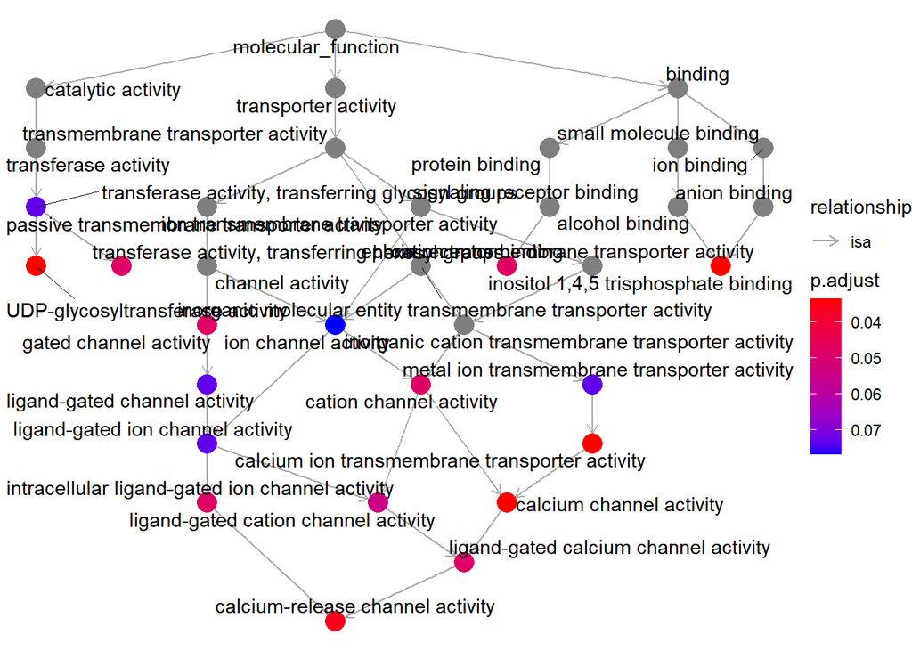

```r
goplot(ego1MF)
```

```r
#Cellular Component
ego1CC <- enrichGO(gene = names(geneList_DESeq1), OrgDb = org.Hs.eg.db,
                   keyType = 'ENSEMBL', ont = "CC", pAdjustMethod = "BH",
                   pvalueCutoff  = 0.1, readable = T)

head(ego1CC)
```

```
##                    ID                    Description GeneRatio   BgRatio
## GO:0031094 GO:0031094 platelet dense tubular network      2/53  11/22283
## GO:0014069 GO:0014069           postsynaptic density      5/53 351/22283
## GO:0098978 GO:0098978          glutamatergic synapse      5/53 354/22283
## GO:0032279 GO:0032279             asymmetric synapse      5/53 357/22283
## GO:0099572 GO:0099572    postsynaptic specialization      5/53 374/22283
## GO:0098984 GO:0098984       neuron to neuron synapse      5/53 383/22283
##                  pvalue   p.adjust     qvalue                         geneID
## GO:0031094 0.0003011264 0.03733967 0.02852776                    ITPR3/ITPR2
## GO:0014069 0.0014553711 0.04404853 0.03365337  EPHA4/GRIK2/CADM1/CACNG7/NGFR
## GO:0098978 0.0015108912 0.04404853 0.03365337 EPHA4/GRIK2/CACNG7/NTNG1/NPTX2
## GO:0032279 0.0015679603 0.04404853 0.03365337  EPHA4/GRIK2/CADM1/CACNG7/NGFR
## GO:0099572 0.0019218829 0.04404853 0.03365337  EPHA4/GRIK2/CADM1/CACNG7/NGFR
## GO:0098984 0.0021313803 0.04404853 0.03365337  EPHA4/GRIK2/CADM1/CACNG7/NGFR
##            Count
## GO:0031094     2
## GO:0014069     5
## GO:0098978     5
## GO:0032279     5
## GO:0099572     5
## GO:0098984     5
```

```r
#Biological Process
ego1BP <- enrichGO(gene = names(geneList_DESeq1), OrgDb = org.Hs.eg.db,
                   keyType = 'ENSEMBL', ont = "BP", pAdjustMethod = "BH",
                   pvalueCutoff  = 0.1, readable = T)

head(ego1BP)
```

```
##                    ID                                        Description
## GO:0050806 GO:0050806       positive regulation of synaptic transmission
## GO:0008306 GO:0008306                               associative learning
## GO:0002431 GO:0002431 Fc receptor mediated stimulatory signaling pathway
## GO:0006816 GO:0006816                              calcium ion transport
## GO:0060291 GO:0060291                    long-term synaptic potentiation
## GO:0048167 GO:0048167                  regulation of synaptic plasticity
##            GeneRatio   BgRatio       pvalue     p.adjust       qvalue
## GO:0050806      7/51 204/21069 5.808171e-07 0.0008532203 0.0006920894
## GO:0008306      4/51  92/21069 7.271187e-05 0.0405447858 0.0328878919
## GO:0002431      3/51  35/21069 8.280079e-05 0.0405447858 0.0328878919
## GO:0006816      7/51 487/21069 1.621887e-04 0.0523126900 0.0424334242
## GO:0060291      4/51 122/21069 2.166850e-04 0.0523126900 0.0424334242
## GO:0048167      5/51 231/21069 2.363229e-04 0.0523126900 0.0424334242
##                                              geneID Count
## GO:0050806  ITPR3/ABL1/EPHA4/GRIK2/NOG/KISS1/CACNG7     7
## GO:0008306                    ABL1/NOG/B3GAT1/NPTX2     4
## GO:0002431                         NR4A3/ABL1/PLPP4     3
## GO:0006816 ITPR3/ABL1/ITPR2/NALF1/PLPP4/CACNG7/STAC     7
## GO:0060291                     ITPR3/ABL1/EPHA4/NOG     4
## GO:0048167               ITPR3/ABL1/EPHA4/GRIK2/NOG     5
```

#### **Kyoto Encyclopedia of Genes and Genomes (KEGG)**

In order to use the KEGG database, ENSEMBL ID are converted in ENTREZID. An higher p-value threshold (padj < 0.5) is needed because of the low number of DE genes having a smaller p-value.

```r
resSig1_KEGG <- subset(res1, padj < 0.5)
resSig1_KEGG <- resSig1_KEGG[order(resSig1_KEGG$log2FoldChange, decreasing=T), ]

geneList_DESeq1_1 <- resSig1_KEGG$log2FoldChange
names(geneList_DESeq1_1) <- row.names(resSig1_KEGG)

gene_df1 <- bitr(names(geneList_DESeq1_1), fromType = "ENSEMBL",
                 toType = "ENTREZID", OrgDb = org.Hs.eg.db)

geneList_df1 <- resSig1_KEGG$log2FoldChange
names(geneList_df1) <- gene_df1$ENTREZID

kk1 <- enrichKEGG(gene = gene_df1$ENTREZID, organism = 'hsa', pvalueCutoff = 0.1)

head(kk1)
```

```
##                ID             Description GeneRatio  BgRatio       pvalue
## hsa04360 hsa04360           Axon guidance    13/163 182/8390 0.0000506381
## hsa04010 hsa04010  MAPK signaling pathway    16/163 302/8390 0.0002471751
## hsa04514 hsa04514 Cell adhesion molecules    10/163 157/8390 0.0009377425
## hsa04540 hsa04540            Gap junction     7/163  88/8390 0.0015585843
##            p.adjust     qvalue
## hsa04360 0.01296335 0.01236636
## hsa04010 0.03163841 0.03018138
## hsa04514 0.08002069 0.07633553
## hsa04540 0.09974939 0.09515567
##                                                                                       geneID
## hsa04360                   1942/9723/6387/25/5590/2048/2043/219699/5880/4773/3897/2042/22854
## hsa04010 1942/10912/782/7423/6654/2768/22808/51701/7042/5880/7039/1950/59284/59283/4293/4804
## hsa04514                          3385/3696/23308/102723996/22829/3897/23705/3123/4897/22854
## hsa04540                                                 3710/2697/6654/3709/3357/1950/57369
##          Count
## hsa04360    13
## hsa04010    16
## hsa04514    10
## hsa04540     7
```

# DE analysis (IN, SN, SI)

The second analysis is designed focusing on the differences due to the Disease State. In particular, 3 comparisons are carried out:

- Inflamed vs Non-Inflamed
- Stenotic vs Non-Inflamed
- Stenotic vs Inflamed

The Disease State variable is releveled.

The first 2 comparisons use “non-inflamed” as reference level while the third one uses “inflamed” category as reference level.

```r
metadata$Disease.State <- as.factor(metadata$Disease.State)
metadata$Disease.State <- relevel(metadata$Disease.State, "non-inflamed")

metadata$Disease.State1 <- as.factor(metadata$Disease.State)
metadata$Disease.State1 <- relevel(metadata$Disease.State, "inflamed")
```

```r
dds2 <- DESeqDataSetFromMatrix(df1, colData=metadata,
                               design = ~ Gender + Age.Level  + Development.Stage + Disease.State)

rld2 <- rlog(dds2, blind=FALSE)


dds2_SI <- DESeqDataSetFromMatrix(df1, colData=metadata,
                                  design = ~ Gender + Age.Level  + Development.Stage + Disease.State1)

rld2_SI <- rlog(dds2_SI, blind=FALSE)
```

### PCA plots

A principal component analysis (PCA) plot allows to visualize the patterns of variability in the data.

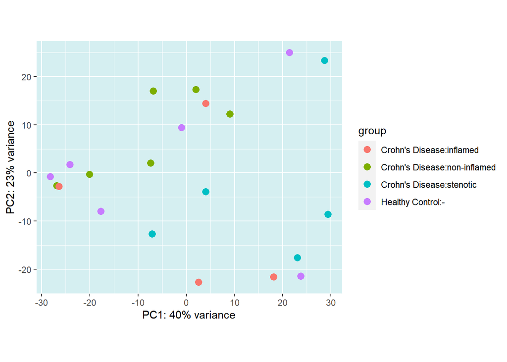

```r
plotPCA(rld2, intgroup = c("Disease", "Disease.State")) +
  theme(panel.background = element_rect(fill = "#d5eff1",colour = "#d5eff1",size = 0.5,
  linetype = "solid"), panel.grid.major = element_line(size = 0.5, linetype = 'solid',
  colour = "white"), panel.grid.minor = element_line(size = 0.25, linetype = 'solid',
  colour = "white"))
```

### DESeq results

**DESeq()** function is applied to perform the actual differential expression analysis and the results are stored in res2 and res2_SI objects.

```r
dds2 <- DESeq(dds2)
res2<-results(dds2)
summary(res2)
```

```
##
## out of 16946 with nonzero total read count
## adjusted p-value < 0.1
## LFC > 0 (up)       : 62, 0.37%
## LFC < 0 (down)     : 400, 2.4%
## outliers [1]       : 0, 0%
## low counts [2]     : 986, 5.8%
## (mean count < 4)
## [1] see 'cooksCutoff' argument of ?results
## [2] see 'independentFiltering' argument of ?results
```

```r
dds2_SI <- DESeq(dds2_SI)
res2_SI <- results(dds2_SI)
summary(res2_SI)
```

```
##
## out of 16946 with nonzero total read count
## adjusted p-value < 0.1
## LFC > 0 (up)       : 5, 0.03%
## LFC < 0 (down)     : 8, 0.047%
## outliers [1]       : 0, 0%
## low counts [2]     : 0, 0%
## (mean count < 1)
## [1] see 'cooksCutoff' argument of ?results
## [2] see 'independentFiltering' argument of ?results
```

For the non-inflamed reference level case, 462 genes show a significant up or down regulation (padj < 0.1).

For the inflamed reference level case, 13 genes show a significant up or down regulation (padj < 0.1).

They are now ordered by a log2FoldChange decreasing order.

```r
resSig2 <- subset(res2, padj < 0.1)
resSig2 <- resSig2[order(resSig2$log2FoldChange, decreasing=T), ]
head(resSig2)
```

```
## log2 fold change (MLE): Disease.State stenotic vs non.inflamed
## Wald test p-value: Disease.State stenotic vs non.inflamed
## DataFrame with 6 rows and 6 columns
##                  baseMean log2FoldChange     lfcSE      stat      pvalue
##                 <numeric>      <numeric> <numeric> <numeric>   <numeric>
## ENSG00000145708  28.27681        8.60290   1.66893   5.15475 2.53970e-07
## ENSG00000164695  12.33566        8.10033   1.85906   4.35723 1.31720e-05
## ENSG00000126860   7.11648        7.61623   2.41609   3.15229 1.61993e-03
## ENSG00000176887   7.68540        7.56285   2.32125   3.25810 1.12162e-03
## ENSG00000198732  37.66274        6.68597   1.53066   4.36803 1.25372e-05
## ENSG00000167889   9.87648        6.43144   1.80069   3.57165 3.54734e-04
##                        padj
##                   <numeric>
## ENSG00000145708 0.000368488
## ENSG00000164695 0.003688165
## ENSG00000126860 0.072037881
## ENSG00000176887 0.060272716
## ENSG00000198732 0.003646837
## ENSG00000167889 0.032010165
```

```r
resSig2_SI <- subset(res2_SI, padj < 0.1)
resSig2_SI <- resSig2_SI[order(resSig2_SI$log2FoldChange, decreasing=T), ]
head(resSig2_SI)
```

```
## log2 fold change (MLE): Disease.State1 stenotic vs inflamed
## Wald test p-value: Disease.State1 stenotic vs inflamed
## DataFrame with 6 rows and 6 columns
##                  baseMean log2FoldChange     lfcSE      stat      pvalue
##                 <numeric>      <numeric> <numeric> <numeric>   <numeric>
## ENSG00000124343   24.1014      10.098226  2.179312   4.63368 3.59230e-06
## ENSG00000145708   28.2768       9.008699  1.947835   4.62498 3.74633e-06
## ENSG00000093072  160.5163       4.519432  1.024016   4.41344 1.01742e-05
## ENSG00000106733   96.3719       1.262328  0.304085   4.15124 3.30683e-05
## ENSG00000114423  238.8705       0.987841  0.236710   4.17321 3.00336e-05
## ENSG00000169116  541.2160      -1.534587  0.368169  -4.16815 3.07075e-05
##                      padj
##                 <numeric>
## ENSG00000124343 0.0126970
## ENSG00000145708 0.0126970
## ENSG00000093072 0.0246302
## ENSG00000106733 0.0505073
## ENSG00000114423 0.0505073
## ENSG00000169116 0.0505073
```

#### **Shrinkage**

Too large log2FoldChange values suggest to perform **shrinkage** for the 3 different comparisons.

```r
#INF vs NINF
res2_inf_noninf <- lfcShrink(dds2, coef="Disease.State_inflamed_vs_non.inflamed", type="normal")

res2_inf_noninf <- subset(res2_inf_noninf, padj < 0.1)
res2_inf_noninf <- res2_inf_noninf[order(res2_inf_noninf$log2FoldChange, decreasing=T), ]
head(res2_inf_noninf)
```

```
## log2 fold change (MAP): Disease.State inflamed vs non.inflamed
## Wald test p-value: Disease.State inflamed vs non.inflamed
## DataFrame with 6 rows and 6 columns
##                  baseMean log2FoldChange     lfcSE      stat      pvalue
##                 <numeric>      <numeric> <numeric> <numeric>   <numeric>
## ENSG00000230423   5.07308      0.3060775  0.211656   7.60636 2.81926e-14
## ENSG00000285283 108.14639      0.1585748  0.174864   7.44226 9.89778e-14
## ENSG00000272872   5.98650      0.0858089  0.213502   4.47994 7.46633e-06
## ENSG00000167889   9.87648     -0.0945793  0.231503  10.48924 9.68022e-26
## ENSG00000164530  27.81706     -0.4075113  0.230347  -4.36359 1.27946e-05
## ENSG00000093072 160.51625     -1.0518760  0.283588  -4.86161 1.16434e-06
##                        padj
##                   <numeric>
## ENSG00000230423 2.38876e-10
## ENSG00000285283 5.59093e-10
## ENSG00000272872 2.10874e-02
## ENSG00000167889 1.64041e-21
## ENSG00000164530 3.09738e-02
## ENSG00000093072 4.93272e-03
```

```r
#STEN vs NINF
res2_sten_noninf <- lfcShrink(dds2, coef = "Disease.State_stenotic_vs_non.inflamed", type = "normal")

res2_sten_noninf <- subset(res2_sten_noninf, padj < 0.1)
res2_sten_noninf <- res2_sten_noninf[order(res2_sten_noninf$log2FoldChange, decreasing=T), ]
head(res2_sten_noninf)
```

```
## log2 fold change (MAP): Disease.State stenotic vs non.inflamed
## Wald test p-value: Disease.State stenotic vs non.inflamed
## DataFrame with 6 rows and 6 columns
##                  baseMean log2FoldChange     lfcSE      stat      pvalue
##                 <numeric>      <numeric> <numeric> <numeric>   <numeric>
## ENSG00000198732  37.66274        1.54130  0.359253   4.36803 1.25372e-05
## ENSG00000228649  38.47960        1.47148  0.291481   4.63141 3.63188e-06
## ENSG00000087510  80.82783        1.46467  0.371064   3.90549 9.40344e-05
## ENSG00000028277  58.90398        1.46025  0.347514   4.17373 2.99657e-05
## ENSG00000165891 261.53894        1.32732  0.360238   4.11886 3.80747e-05
## ENSG00000167889   9.87648        1.25402  0.344447   3.57165 3.54734e-04
##                       padj
##                  <numeric>
## ENSG00000198732 0.00364684
## ENSG00000228649 0.00179943
## ENSG00000087510 0.01305034
## ENSG00000028277 0.00655140
## ENSG00000165891 0.00759590
## ENSG00000167889 0.03201017
```

```r
#STEN vs INF
res2_sten_inf <- lfcShrink(dds2_SI, coef = "Disease.State1_stenotic_vs_inflamed", type = "normal")

res2_sten_inf <- subset(res2_sten_inf, padj < 0.1)
res2_sten_inf <- res2_sten_inf[order(res2_sten_inf$log2FoldChange, decreasing=T), ]
head(res2_sten_inf)
```

```
## log2 fold change (MAP): Disease.State1 stenotic vs inflamed
## Wald test p-value: Disease.State1 stenotic vs inflamed
## DataFrame with 6 rows and 6 columns
##                  baseMean log2FoldChange     lfcSE      stat      pvalue
##                 <numeric>      <numeric> <numeric> <numeric>   <numeric>
## ENSG00000106733  96.37188     0.84128648  0.211657   4.15124 3.30683e-05
## ENSG00000167889   9.87648     0.79046691  0.215082  -7.95043 1.85865e-15
## ENSG00000114423 238.87053     0.75362063  0.185111   4.17321 3.00336e-05
## ENSG00000093072 160.51625     0.21057884  0.262636   4.41344 1.01742e-05
## ENSG00000124343  24.10137     0.00969045  0.201514   4.63368 3.59230e-06
## ENSG00000145708  28.27681    -0.01141310  0.217036   4.62498 3.74633e-06
##                        padj
##                   <numeric>
## ENSG00000106733 5.05073e-02
## ENSG00000167889 3.14966e-11
## ENSG00000114423 5.05073e-02
## ENSG00000093072 2.46302e-02
## ENSG00000124343 1.26970e-02
## ENSG00000145708 1.26970e-02
```

The following code is used to investigate if there are genes that show a value of expression in a condition that is half or double compared to its expression in the other condition. In this case, 12 genes are expressed in Chron’s disease samples with a value that is half of the expression observed among controls while just 1 shows a double expression.

```r
resLFC2 <- results(dds2, lfcThreshold=1)
summary(resLFC2)
```

```
##
## out of 16946 with nonzero total read count
## adjusted p-value < 0.1
## LFC > 1.00 (up)    : 1, 0.0059%
## LFC < -1.00 (down) : 12, 0.071%
## outliers [1]       : 0, 0%
## low counts [2]     : 0, 0%
## (mean count < 1)
## [1] see 'cooksCutoff' argument of ?results
## [2] see 'independentFiltering' argument of ?results
```

### Plot results

#### **Dot plots**

The read counts of the gene with the smallest padj, one for each comparison, are plotted.

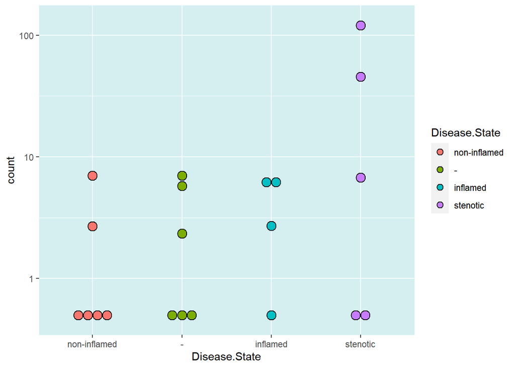

```r
#INF vs NINF
topGenes2_IN<-rownames(res2_inf_noninf[order(res2_inf_noninf$padj),])
geneCounts2_IN <- plotCounts(dds2, gene=topGenes2_IN[1],
                             intgroup=c("Disease.State"), returnData=T)
ggplot(geneCounts2_IN, aes(x=Disease.State, y=count, fill=Disease.State)) +
  scale_y_log10() + geom_dotplot(binaxis="y", stackdir="center") +
  theme(panel.background = element_rect(fill = "#d5eff1",colour = "#d5eff1",size = 0.5,
  linetype = "solid"), panel.grid.major = element_line(size = 0.5, linetype = 'solid',
  colour = "white"), panel.grid.minor = element_line(size = 0.25, linetype = 'solid',
  colour = "white"))
```

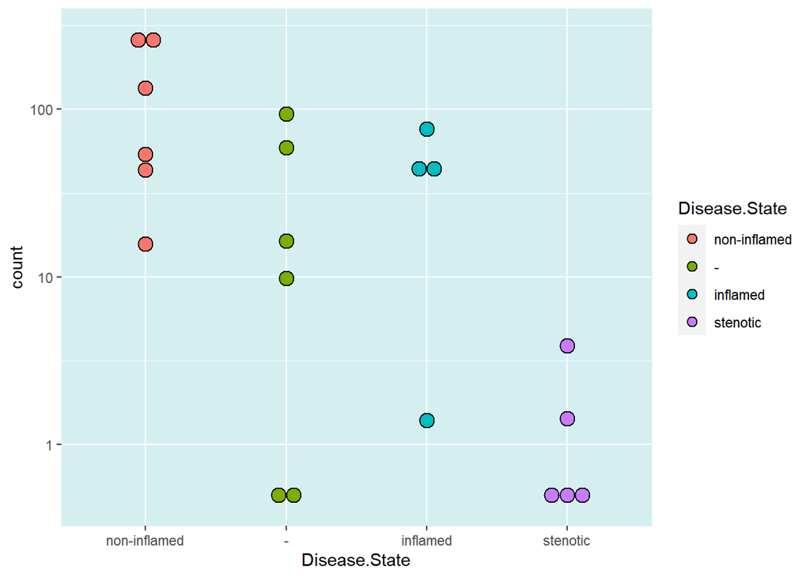

```r
#STEN vs NINF
topGenes2_SN<-rownames(res2_sten_noninf[order(res2_sten_noninf$padj),])
geneCounts2_SN <- plotCounts(dds2, gene=topGenes2_SN[1],
                             intgroup=c("Disease.State"), returnData=T)
ggplot(geneCounts2_SN, aes(x=Disease.State, y=count, fill=Disease.State)) +
  scale_y_log10() + geom_dotplot(binaxis="y", stackdir="center") +
  theme(panel.background = element_rect(fill = "#d5eff1",colour = "#d5eff1",size = 0.5,
  linetype = "solid"), panel.grid.major = element_line(size = 0.5, linetype = 'solid',
  colour = "white"), panel.grid.minor = element_line(size = 0.25, linetype = 'solid',
  colour = "white"))
```

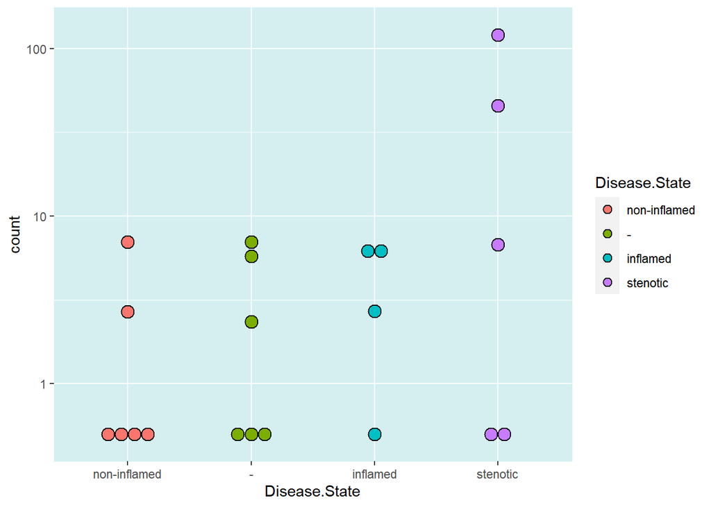

```r
#STEN vs INF
topGenes2_SI<-rownames(res2_sten_inf[order(res2_sten_inf$padj),])
geneCounts2_SI <- plotCounts(dds2_SI, gene=topGenes2_SI[1],
                             intgroup=c("Disease.State"), returnData=T)
ggplot(geneCounts2_SI, aes(x=Disease.State, y=count, fill=Disease.State)) +
  scale_y_log10() + geom_dotplot(binaxis="y", stackdir="center") +
  theme(panel.background = element_rect(fill = "#d5eff1",colour = "#d5eff1",size = 0.5,
  linetype = "solid"), panel.grid.major = element_line(size = 0.5, linetype = 'solid',
  colour = "white"), panel.grid.minor = element_line(size = 0.25, linetype = 'solid',
  colour = "white"))
```

#### **MA plots**

The MA plot represents the LFC of the genes as a function of the average expression between the two conditions, which are theoretically equivalent information between the two experimental conditions.

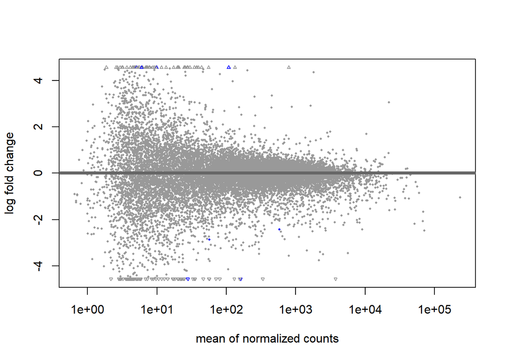

```r
#INF vs NINF
res2_IN_MA <- results(dds2,
                      contrast = list("Disease.State_inflamed_vs_non.inflamed"))
DESeq2::plotMA(res2_IN_MA)
```

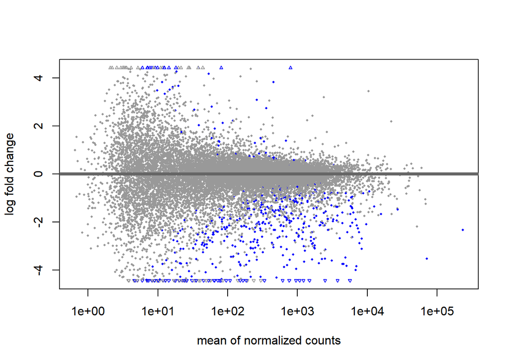

```r
#STEN vs NINF
res2_SN_MA <- results(dds2,
                      contrast = list("Disease.State_stenotic_vs_non.inflamed"))
DESeq2::plotMA(res2_SN_MA)
```

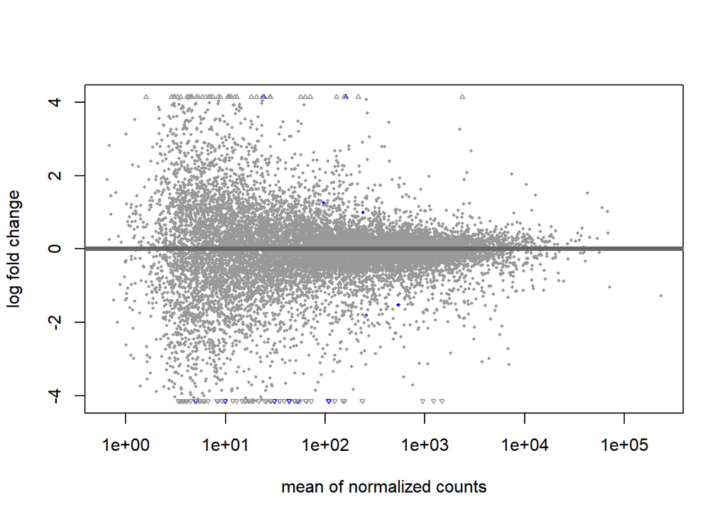

```r
#STEN vs INF
res2_SI_MA <- results(dds2_SI,
                      contrast = list("Disease.State1_stenotic_vs_inflamed"))
DESeq2::plotMA(res2_SI_MA)
```

#### **P-value distribution**

An histogram of p-values distribution is plotted to investigate the reliability of the analysis.

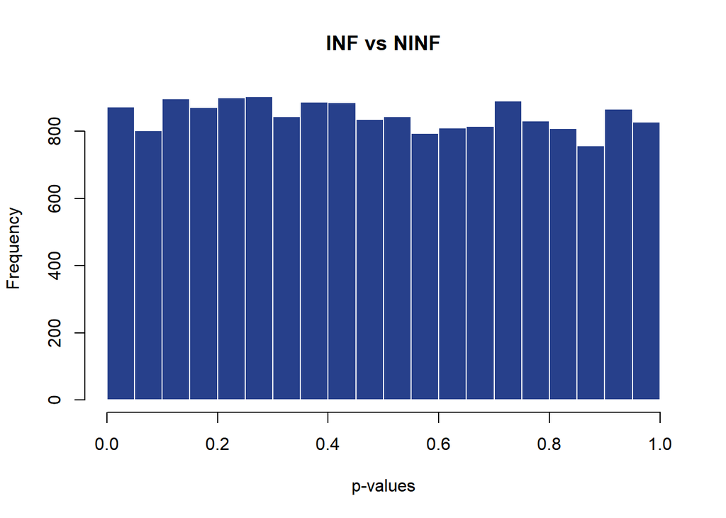

```r
#INF vs NINF
hist(res2_IN_MA$pvalue[res2_IN_MA$baseMean > 1], breaks=0:20/20, col="royalblue4", border="white", main = "INF vs NINF", xlab = "p-values")
```

```r
res2_IN_corr <- res2_IN_MA[ !is.na(res2_IN_MA$padj),]
res2_IN_corr <- res2_IN_corr[ !is.na(res2_IN_corr$pvalue), ]
res2_IN_corr <- res2_IN_corr[, -which(names(res2_IN_corr) == "padj")]
res_fdr2_IN<- fdrtool(res2_IN_corr$stat, statistic= "normal", plot = F)
```

```
## Step 1... determine cutoff point
## Step 2... estimate parameters of null distribution and eta0
## Step 3... compute p-values and estimate empirical PDF/CDF
## Step 4... compute q-values and local fdr
```

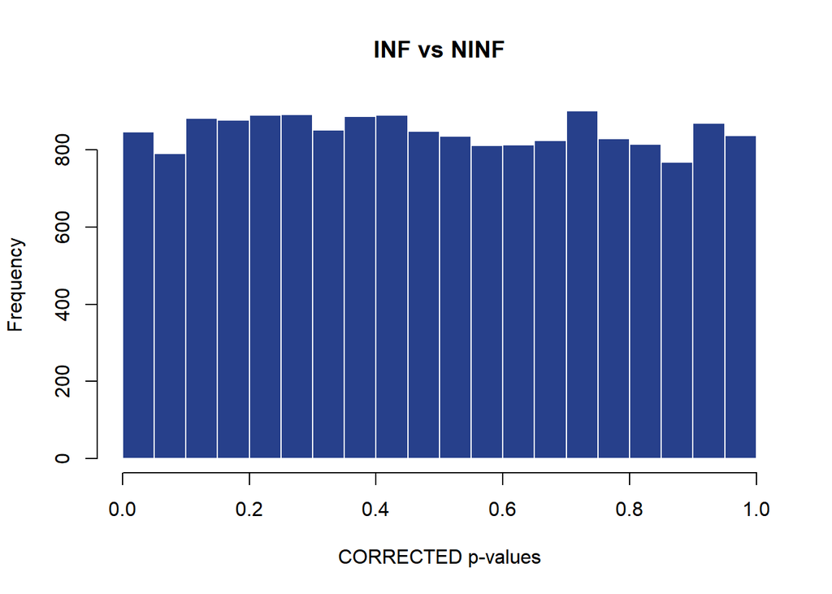

```r
res2_IN_corr[,"padj"] <- p.adjust(res_fdr2_IN$pval, method = "BH")
hist(res_fdr2_IN$pval, col = "royalblue4", main = "INF vs NINF", xlab = "CORRECTED p-values", border="white")
```

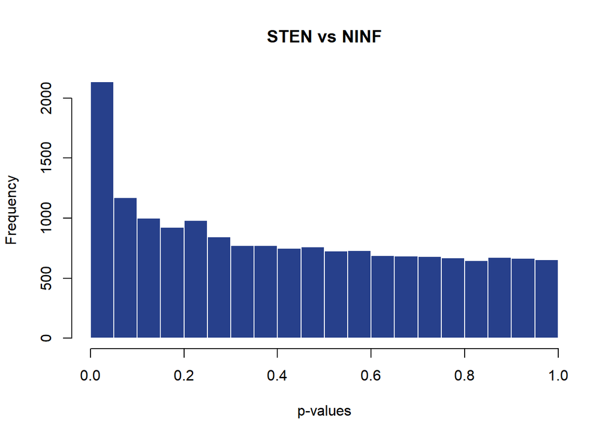

```r
#STEN vs NINF
hist(res2_SN_MA$pvalue[res2_SN_MA$baseMean > 1], breaks=0:20/20, col="royalblue4", border="white", main = "STEN vs NINF", xlab = "p-values")
```

```r
res2_SN_corr <- res2_SN_MA[ !is.na(res2_SN_MA$padj),]
res2_SN_corr <- res2_SN_corr[ !is.na(res2_SN_corr$pvalue), ]
res2_SN_corr <- res2_SN_corr[, -which(names(res2_SN_corr) == "padj")]
res_fdr2_SN <- fdrtool(res2_SN_corr$stat, statistic= "normal", plot = F)
```

```
## Step 1... determine cutoff point
## Step 2... estimate parameters of null distribution and eta0
## Step 3... compute p-values and estimate empirical PDF/CDF
## Step 4... compute q-values and local fdr
```

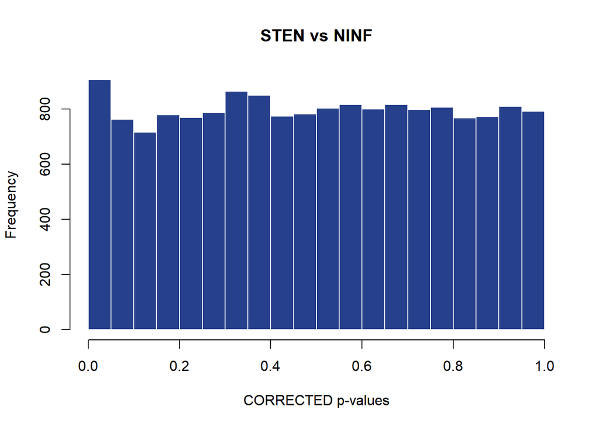

```r
res2_SN_corr[,"padj"] <- p.adjust(res_fdr2_SN$pval, method = "BH")
hist(res_fdr2_SN$pval, col = "royalblue4", main = "STEN vs NINF", xlab = "CORRECTED p-values", border="white")
```

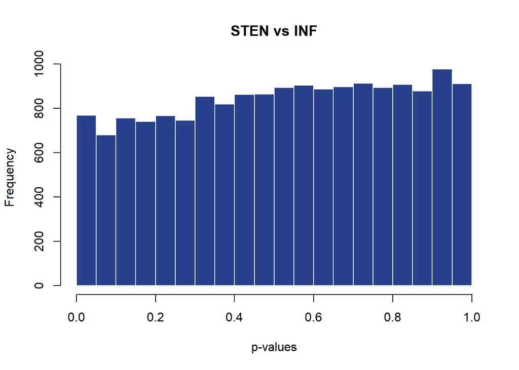

```r
#STEN vs INF
hist(res2_SI_MA$pvalue[res2_SI_MA$baseMean > 1], breaks=0:20/20, col="royalblue4", border="white", main = "STEN vs INF", xlab = "p-values")
```

```r
res2_SI_corr <- res2_SI_MA[ !is.na(res2_SI_MA$padj),]
res2_SI_corr <- res2_SI_corr[ !is.na(res2_SI_corr$pvalue), ]
res2_SI_corr <- res2_SI_corr[, -which(names(res2_SI_corr) == "padj")]
res_fdr2_SI <- fdrtool(res2_SI_corr$stat, statistic= "normal", plot = F)
```

```
## Step 1... determine cutoff point
## Step 2... estimate parameters of null distribution and eta0
## Step 3... compute p-values and estimate empirical PDF/CDF
## Step 4... compute q-values and local fdr
```

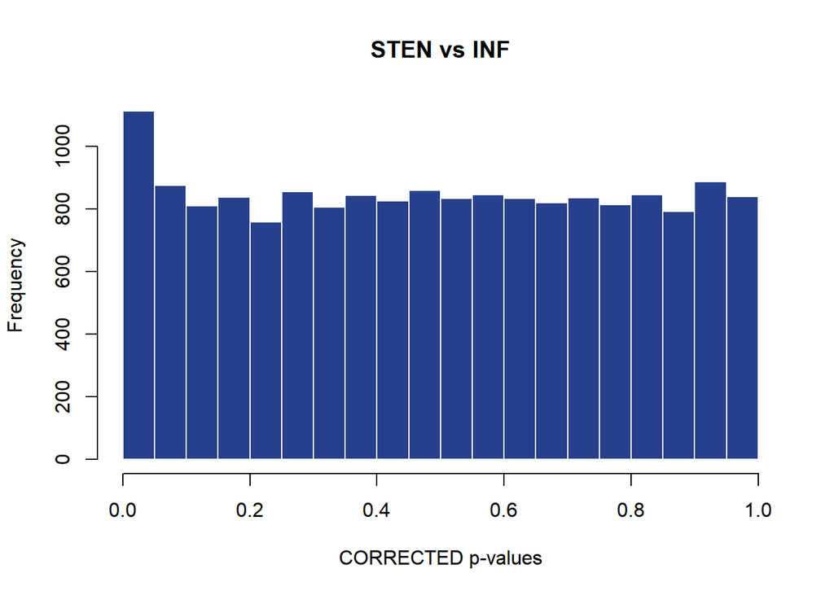

```r
res2_SI_corr[,"padj"] <- p.adjust(res_fdr2_SI$pval, method = "BH")
hist(res_fdr2_SI$pval, col = "royalblue4", main = "STEN vs INF", xlab = "CORRECTED p-values", border="white")
```